# Exploring the NOAA Storm Database : Health and Economic impacts of Severe Weather Events in the U.S.

Sreyashi Banik

6 June 2019

## **Assignment**

```
The basic goal of this assignment is to explore the NOAA Storm Database and answer the following basic questions about severe weather events.

* Across the United States, which types of events (as indicated in the EVTYPE variable) are most harmful with respect to population health?
* Across the United States, which types of events have the greatest economic consequences?
```

## **Synopsis**

Storms and other severe weather events can cause both public health and economic problems for communities and municipalities.

This project involves exploring the U.S. National Oceanic and Atmospheric Administration’s (NOAA) storm database. This database tracks characteristics of major storms and weather events in the United States, including when and where they occur, as well as estimates of any fatalities, injuries, and property damage.

This analysis shows by aggregating the data by storm events type:

- **Tornados** are the most harmful events on population health (including injury and fatalities) as well as are responsible for the most economic damage.

## **Data Processing**

### **Loading libraries**

I have used these libraries in my analysis:

```r
library(dplyr)
library(RColorBrewer)
```

### **Data**

The data for this assignment come in the form of a comma-separated-value file compressed via the bzip2 algorithm to reduce its size. You can download the file from the course web site:

[Storm Data](https://d396qusza40orc.cloudfront.net/repdata%2Fdata%2FStormData.csv.bz2)[47Mb]

There is also some documentation of the database available. Here you will find how some of the variables are constructed / defined.

- National Weather Service [Storm Data Documentation](https://d396qusza40orc.cloudfront.net/repdata%2Fpeer2_doc%2Fpd01016005curr.pdf)
- National Climatic Data Center Storm Events [FAQ](https://d396qusza40orc.cloudfront.net/repdata%2Fpeer2_doc%2FNCDC%20Storm%20Events-FAQ%20Page.pdf)

The events in the database start in the year 1950 and end in November 2011. In the earlier years of the database there are generally fewer events recorded, most likely due to a lack of good records. More recent years should be considered more complete.

### **Downloading the data**

First the data have been downloaded from the website(if it has not been downloaded already):

```r
if (!file.exists("Strom_Data.csv.bz2")){
download.file("https://d396qusza40orc.cloudfront.net/repdata%2Fdata%2FStormData.csv.bz2",destfile ="C://Users//User//Documents//Strom_Data.csv.bz2" )
}
```

### **Loading the data**

Then the downloaded data is loaded on R using the read.csv command. If object it is already loaded, then the cached object is used insted of loading it each time the Rmd file is knitted.

```r
StromData<-read.csv(bzfile("Strom_Data.csv.bz2"),header = TRUE)
```

### **Examining The dimension of the data**

In the data.frame StromData, there are 37 columns (variables) and 414626 rows (observations).

```r
dim(StromData)
```

```
## [1] 414626     37
```

### **Extracting required variables for analysis of weather impact on health and economy**

From a list of variables in StromData, these are columns of interest:

Health variables:  
* FATALITIES: approx. number of deaths  
* INJURIES: approx. number of injuries

Economic variables:

- PROPDMG: approx. property damages
- PROPDMGEXP: the units for property damage value
- CROPDMG: approx. crop damages
- CROPDMGEXP: the units for crop damage value

Events - target variable:

- EVTYPE: weather event (Tornados, Wind, Snow, Flood, etc..)

Extract variables of interest from original data set:

```r
StromData<-select(StromData,EVTYPE,FATALITIES:CROPDMGEXP)
```

### **Examining few Rows (Observations) of the new data.frame**

Check the first few rows in data set:

```r
head(StromData)
```

```
##    EVTYPE FATALITIES INJURIES PROPDMG PROPDMGEXP CROPDMG CROPDMGEXP
## 1 TORNADO          0       15    25.0          K       0
## 2 TORNADO          0        0     2.5          K       0
## 3 TORNADO          0        2    25.0          K       0
## 4 TORNADO          0        2     2.5          K       0
## 5 TORNADO          0        2     2.5          K       0
## 6 TORNADO          0        6     2.5          K       0
```

### **Examining the structure of the new data.frame**

Check inner structure of the data set:

```r
str(StromData)
```

```
## 'data.frame':    414626 obs. of  7 variables:
##  $ EVTYPE    : Factor w/ 931 levels " COASTAL FLOOD",..: 790 790 790 790 790 790 790 790 790 790 ...
##  $ FATALITIES: num  0 0 0 0 0 0 0 0 1 0 ...
##  $ INJURIES  : num  15 0 2 2 2 6 1 0 14 0 ...
##  $ PROPDMG   : num  25 2.5 25 2.5 2.5 2.5 2.5 2.5 25 25 ...
##  $ PROPDMGEXP: Factor w/ 19 levels "","-","?","+",..: 17 17 17 17 17 17 17 17 17 17 ...
##  $ CROPDMG   : num  0 0 0 0 0 0 0 0 0 0 ...
##  $ CROPDMGEXP: Factor w/ 9 levels "","?","0","2",..: 1 1 1 1 1 1 1 1 1 1 ...
```

### **Transforming Event Type Variable**

Let’s check the top 10 event types that appears most frequently in the rows(observations):

```r
sort(table(StromData$EVTYPE), decreasing = TRUE)[1:10]
```

```
##
##          TSTM WIND               HAIL            TORNADO
##             147431             134403              44203
## THUNDERSTORM WINDS        FLASH FLOOD          LIGHTNING
##              20843              15923               7006
##              FLOOD         HEAVY SNOW          HIGH WIND
##               6307               5650               4778
##         HEAVY RAIN
##               2638
```

We will group events like TUNDERSTORM WIND, TUNDERSTORM WINDS, TSTM WIND etc. into one event “Thunderstorm Wind”.We will transform the other events in a similar way. The events that was not categorized by any specific type of events are grouped into a new event named “Others”.

```r
# Copying actual data.frame
TEMP<-StromData

# Creating a new variable(column) "EVNAME" and assigning "Others" as it's default value
TEMP$EVNAME<-"Others"

# Grouping events by similar type of keywords
TEMP$EVNAME[grep("AVALANCE|AVALANCHE",TEMP$EVTYPE,ignore.case = TRUE)]<-"Avalanche"
TEMP$EVNAME[grep("BLIZZARD",TEMP$EVTYPE,ignore.case = TRUE)]<-"Blizzard"
TEMP$EVNAME[grep("FLOOD|FLOODING|FLOOODING|FLOODS|EXCESSIVE RAIN|EXCESSIVE PRECIPITATION|HEAVY RAIN|HEAVY PRECIPITATION|HEAVY PRECIPATATION|RAIN|HEAVY SHOWER",TEMP$EVTYPE,ignore.case = TRUE)]<-"Flood and Heavy Rain"
TEMP$EVNAME[grep("COASTAL|BEACH|TIDAL FLOOD|EROSION|HIGH SEA|HIGH SURF|HEAVY SURF|HEAVY SWELLS|HIGH  SWELLS|STROM SURGE|HIGH SWELLS|TIDE",TEMP$EVTYPE,ignore.case = TRUE)]<-"Coastal Flood and Strom"
TEMP$EVNAME[grep("COLD|WIND CHILL|WINDCHILL",TEMP$EVTYPE,ignore.case = TRUE)]<-"Cold and Wind Chill"
TEMP$EVNAME[grep("BELOW NORMAL PRECIPITATION|DROUGHT|DRY|EXCESSIVE HEAT|EXCESSIVELY DRY|EXTREME HEAT|HEAT",TEMP$EVTYPE,ignore.case = TRUE)]<-"Drought and Heat"
TEMP$EVNAME[grep("Dust",TEMP$EVTYPE,ignore.case = TRUE)]<-"Dust Devil and Dust Storm"
TEMP$EVNAME[grep("FOG",TEMP$EVTYPE,ignore.case = TRUE)]<-"Fog"
TEMP$EVNAME[grep("FROST|FREEZE|FREEZING",TEMP$EVTYPE,ignore.case = TRUE)]<-"Frost and Freeze"
TEMP$EVNAME[grep("FUNNEL|WATERSPOUT|WAYTERSPOUT|WATER SPOUT",TEMP$EVTYPE,ignore.case = TRUE)]<-"Funnel Cloud and Waterspout"
TEMP$EVNAME[grep("HAIL",TEMP$EVTYPE,ignore.case = TRUE)]<-"Hail"
TEMP$EVNAME[grep("HIGH W|HIGH WIND|WIND",TEMP$EVTYPE,ignore.case = TRUE)]<-"High Wind"
TEMP$EVNAME[grep("HURRICANE|TYPHOON",TEMP$EVTYPE,ignore.case = TRUE)]<-"Hurricane and Typhoon"
TEMP$EVNAME[grep("LAKE|SEICHE",TEMP$EVTYPE,ignore.case = TRUE)]<-"Lake Effect Snow, Lake Flood and Seiche"
TEMP$EVNAME[grep("LIGHTING|LIGHTNING|LIGNTNING",TEMP$EVTYPE,ignore.case = TRUE)]<-"Lightning"
TEMP$EVNAME[grep("RIP CURRENT|GRADIENT WIND",TEMP$EVTYPE,ignore.case = TRUE)]<-"Rip Current and Gradient Wind"
TEMP$EVNAME[grep("SNOW|ICE|SLEET",TEMP$EVTYPE,ignore.case = TRUE)]<-"Snow, Ice and Sleet"
TEMP$EVNAME[grep("STRONG WIND",TEMP$EVTYPE,ignore.case = TRUE)]<-"Strong Wind"
TEMP$EVNAME[grep("THUNDERSTORM W|THUNDERSTORM WIND|THUNDERSTORMW|THUNDERSTROM WIND|THUNDERTORM WINDS|THUNDERTSORM WIND|THUNDESTORM WIND|THUNERSTORM WIND|TSTM WIND|TUNDERSTORM WIND|TSTM|GUSTNADO|GUSTY",TEMP$EVTYPE,ignore.case = TRUE)]<-"Thunderstorm Wind"
TEMP$EVNAME[grep("TORNADO|TORNDAO",TEMP$EVTYPE,ignore.case = TRUE)]<-"Tornado"
TEMP$EVNAME[grep("TROPICAL",TEMP$EVTYPE,ignore.case = TRUE)]<-"Tropical Depression and Storm"
TEMP$EVNAME[grep("VOG,VOLCANIC",TEMP$EVTYPE,ignore.case = TRUE)]<-"Volcanic Eruption"
TEMP$EVNAME[grep("WILDFIRE|WILD FIRES|FOREST FIRE|FIRE",TEMP$EVTYPE,ignore.case = TRUE)]<-"Wildfire"
TEMP$EVNAME[grep("WINTER|WINTRY|WINTERY",TEMP$EVTYPE,ignore.case = TRUE)]<-"Winter Weather and Strom"

# Listing all events in "EVNAME"
sort(unique(TEMP$EVNAME))
```

```
##  [1] "Avalanche"
##  [2] "Blizzard"
##  [3] "Coastal Flood and Strom"
##  [4] "Cold and Wind Chill"
##  [5] "Drought and Heat"
##  [6] "Dust Devil and Dust Storm"
##  [7] "Flood and Heavy Rain"
##  [8] "Fog"
##  [9] "Frost and Freeze"
## [10] "Funnel Cloud and Waterspout"
## [11] "Hail"
## [12] "High Wind"
## [13] "Hurricane and Typhoon"
## [14] "Lake Effect Snow, Lake Flood and Seiche"
## [15] "Lightning"
## [16] "Others"
## [17] "Rip Current and Gradient Wind"
## [18] "Snow, Ice and Sleet"
## [19] "Strong Wind"
## [20] "Thunderstorm Wind"
## [21] "Tornado"
## [22] "Tropical Depression and Storm"
## [23] "Wildfire"
## [24] "Winter Weather and Strom"
```

So, there are total 24 different type of events in the new data.frame.

Let’s take a look at damage exponents:

```r
sort(unique(TEMP$PROPDMGEXP))
```

```
##  [1]   - ? + 0 1 2 3 4 5 6 7 8 B h H K m M
## Levels:  - ? + 0 1 2 3 4 5 6 7 8 B h H K m M
```

```r
sort(unique(TEMP$CROPDMGEXP))
```

```
## [1]   ? 0 2 B k K m M
## Levels:  ? 0 2 B k K m M
```

So we can see there are 10 different valid exponents, they are: 0, 1,2 or H or h, 3 or K OR k, 4, 5, 6 or M or m, 7, 8 and B

Now we have to multiply the exponent parts with damage value to get total property damage.

```r
# Setting default value 0 to total property damage variable
TEMP$TOTALPROPDMG=0

# Multiplying exponent and value part to get total property damage
TEMP$TOTALPROPDMG[grep("0",TEMP$PROPDMGEXP,ignore.case = TRUE)]<-TEMP$PROPDMG[grep("0",TEMP$PROPDMGEXP,ignore.case = TRUE)]*10^0
TEMP$TOTALPROPDMG[grep("1",TEMP$PROPDMGEXP,ignore.case = TRUE)]<-TEMP$PROPDMG[grep("1",TEMP$PROPDMGEXP,ignore.case = TRUE)]*10^1
TEMP$TOTALPROPDMG[grep("H|2",TEMP$PROPDMGEXP,ignore.case = TRUE)]<-TEMP$PROPDMG[grep("H|2",TEMP$PROPDMGEXP,ignore.case = TRUE)]*10^2
TEMP$TOTALPROPDMG[grep("K|3",TEMP$PROPDMGEXP,ignore.case = TRUE)]<-TEMP$PROPDMG[grep("K|3",TEMP$PROPDMGEXP,ignore.case = TRUE)]*10^3
TEMP$TOTALPROPDMG[grep("4",TEMP$PROPDMGEXP,ignore.case = TRUE)]<-TEMP$PROPDMG[grep("4",TEMP$PROPDMGEXP,ignore.case = TRUE)]*10^4
TEMP$TOTALPROPDMG[grep("5",TEMP$PROPDMGEXP,ignore.case = TRUE)]<-TEMP$PROPDMG[grep("5",TEMP$PROPDMGEXP,ignore.case = TRUE)]*10^5
TEMP$TOTALPROPDMG[grep("M|6",TEMP$PROPDMGEXP,ignore.case = TRUE)]<-TEMP$PROPDMG[grep("M|6",TEMP$PROPDMGEXP,ignore.case = TRUE)]*10^6
TEMP$TOTALPROPDMG[grep("7",TEMP$PROPDMGEXP,ignore.case = TRUE)]<-TEMP$PROPDMG[grep("7",TEMP$PROPDMGEXP,ignore.case = TRUE)]*10^7
TEMP$TOTALPROPDMG[grep("8",TEMP$PROPDMGEXP,ignore.case = TRUE)]<-TEMP$PROPDMG[grep("8",TEMP$PROPDMGEXP,ignore.case = TRUE)]*10^8
TEMP$TOTALPROPDMG[grep("B",TEMP$PROPDMGEXP,ignore.case = TRUE)]<-TEMP$PROPDMG[grep("B",TEMP$PROPDMGEXP,ignore.case = TRUE)]*10^9

# Checking Total property damage for first few observations
head(TEMP$TOTALPROPDMG)
```

```
## [1] 25000  2500 25000  2500  2500  2500
```

Similarly we will calculate total crop damage:

```r
# Setting default value 0 to total crop damage variable
TEMP$TOTALCROPDMG=0

# Multiplying exponent and value part to get total crop damage
TEMP$TOTALCROPDMG[grep("0",TEMP$CROPDMGEXP,ignore.case = TRUE)]<-TEMP$CROPDMG[grep("0",TEMP$CROPDMGEXP,ignore.case = TRUE)]*10^0
TEMP$TOTALCROPDMG[grep("2",TEMP$CROPDMGEXP,ignore.case = TRUE)]<-TEMP$CROPDMG[grep("2",TEMP$CROPDMGEXP,ignore.case = TRUE)]*10^2
TEMP$TOTALCROPDMG[grep("K",TEMP$CROPDMGEXP,ignore.case = TRUE)]<-TEMP$CROPDMG[grep("K",TEMP$CROPDMGEXP,ignore.case = TRUE)]*10^3
TEMP$TOTALCROPDMG[grep("M",TEMP$CROPDMGEXP,ignore.case = TRUE)]<-TEMP$CROPDMG[grep("M",TEMP$CROPDMGEXP,ignore.case = TRUE)]*10^6
TEMP$TOTALCROPDMG[grep("B",TEMP$CROPDMGEXP,ignore.case = TRUE)]<-TEMP$CROPDMG[grep("B",TEMP$CROPDMGEXP,ignore.case = TRUE)]*10^9

# Checking Total crop damage for first few observations
head(TEMP$TOTALCROPDMG)
```

```
## [1] 0 0 0 0 0 0
```

## **Analysis**

Let’s see which event caused most number of injuries. We will aggregate total number of injuries by Events.

```r
injuries <- aggregate(INJURIES ~ EVNAME, data=TEMP, sum)
injuries <- injuries[order(-injuries$INJURIES), ]
injuries
```

```
##                                     EVNAME INJURIES
## 21                                 Tornado    77183
## 7                     Flood and Heavy Rain     7661
## 20                       Thunderstorm Wind     6627
## 5                         Drought and Heat     4782
## 18                     Snow, Ice and Sleet     2956
## 15                               Lightning     2629
## 24                Winter Weather and Strom     1164
## 12                               High Wind      980
## 11                                    Hail      883
## 2                                 Blizzard      785
## 8                                      Fog      721
## 23                                Wildfire      509
## 16                                  Others      416
## 4                      Cold and Wind Chill      279
## 6                Dust Devil and Dust Storm      233
## 17           Rip Current and Gradient Wind      163
## 22           Tropical Depression and Storm      116
## 1                                Avalanche       65
## 3                  Coastal Flood and Strom       58
## 19                             Strong Wind       56
## 13                   Hurricane and Typhoon       42
## 9                         Frost and Freeze       41
## 10             Funnel Cloud and Waterspout       31
## 14 Lake Effect Snow, Lake Flood and Seiche        0
```

So **Tornado** caused more number of injuries than other events, followed by **Flood and Heavy Rain** and **Thunderstorm Wind** respectively.

Now find out which event caused most number of fatalities.

```r
fatalities <- aggregate(FATALITIES ~ EVNAME, data=TEMP, sum)
fatalities <- fatalities[order(-fatalities$FATALITIES), ]
fatalities
```

```
##                                     EVNAME FATALITIES
## 21                                 Tornado       4515
## 5                         Drought and Heat       2082
## 7                     Flood and Heavy Rain        754
## 20                       Thunderstorm Wind        493
## 15                               Lightning        405
## 12                               High Wind        224
## 18                     Snow, Ice and Sleet        214
## 4                      Cold and Wind Chill        195
## 17           Rip Current and Gradient Wind        145
## 24                Winter Weather and Strom        142
## 16                                  Others        100
## 2                                 Blizzard         85
## 1                                Avalanche         67
## 13                   Hurricane and Typhoon         67
## 8                                      Fog         43
## 3                  Coastal Flood and Strom         41
## 22           Tropical Depression and Storm         16
## 6                Dust Devil and Dust Storm         13
## 9                         Frost and Freeze         12
## 11                                    Hail         12
## 19                             Strong Wind         12
## 23                                Wildfire          9
## 10             Funnel Cloud and Waterspout          3
## 14 Lake Effect Snow, Lake Flood and Seiche          0
```

Most fatalities were caused due by **Tornado** , followed by **Drought and Heat** and **Flood and Heavy Rain** respectively.

Now we are going to look at events that caused most property damage.

```r
propertydamage<-aggregate(TOTALPROPDMG~EVNAME,data =TEMP,sum)
propertydamage<-propertydamage[order(-propertydamage$TOTALPROPDMG),]
propertydamage
```

```
##                                     EVNAME TOTALPROPDMG
## 21                                 Tornado  39581149804
## 7                     Flood and Heavy Rain  25182445439
## 13                   Hurricane and Typhoon  13013065000
## 24                Winter Weather and Strom   5379762551
## 20                       Thunderstorm Wind   4669975573
## 11                                    Hail   4434578596
## 23                                Wildfire   3498508700
## 18                     Snow, Ice and Sleet   2718414570
## 16                                  Others   1421921850
## 12                               High Wind   1117588660
## 2                                 Blizzard    539340950
## 22           Tropical Depression and Storm    520610000
## 15                               Lightning    378734467
## 3                  Coastal Flood and Strom    232461150
## 5                         Drought and Heat    221030650
## 4                      Cold and Wind Chill    124088400
## 9                         Frost and Freeze     18397500
## 8                                      Fog     10252500
## 19                             Strong Wind      8499290
## 10             Funnel Cloud and Waterspout      4451000
## 6                Dust Devil and Dust Storm      1524600
## 1                                Avalanche       994500
## 14 Lake Effect Snow, Lake Flood and Seiche       850000
## 17           Rip Current and Gradient Wind        39000
```

Most harmful events causing highest property damage is **Tornado**, **Flood and Heavy Rain** is close second followed by **Hurricane and Typhoon**.

```r
cropdamage<-aggregate(TOTALCROPDMG~EVNAME,data =TEMP,sum)
cropdamage<-cropdamage[order(-cropdamage$TOTALCROPDMG),]
cropdamage
```

```
##                                     EVNAME TOTALCROPDMG
## 7                     Flood and Heavy Rain   8216946000
## 5                         Drought and Heat   7686973780
## 18                     Snow, Ice and Sleet   5152802400
## 13                   Hurricane and Typhoon   2459285000
## 11                                    Hail   1381824770
## 4                      Cold and Wind Chill   1254425500
## 9                         Frost and Freeze    855125000
## 20                       Thunderstorm Wind    614604430
## 12                               High Wind    303391050
## 22           Tropical Depression and Storm    282635000
## 21                                 Tornado    189461110
## 16                                  Others    174630500
## 2                                 Blizzard    112060000
## 23                                Wildfire    105802200
## 24                Winter Weather and Strom     31791000
## 15                               Lightning      8811490
## 19                             Strong Wind      5000000
## 3                  Coastal Flood and Strom      1556000
## 6                Dust Devil and Dust Storm       100000
## 1                                Avalanche            0
## 8                                      Fog            0
## 10             Funnel Cloud and Waterspout            0
## 14 Lake Effect Snow, Lake Flood and Seiche            0
## 17           Rip Current and Gradient Wind            0
```

**Flood and Heavy Rain** have caused most crop damage followed by **Drought and Heat** and **Snow, Ice and Sleet**.

## **Results**

**Across the United States, which types of events (as indicated in the EVTYPE variable) are most harmful with respect to population health ?**

First, We will plot a piechart for 5 most deadliest event causing injuries:

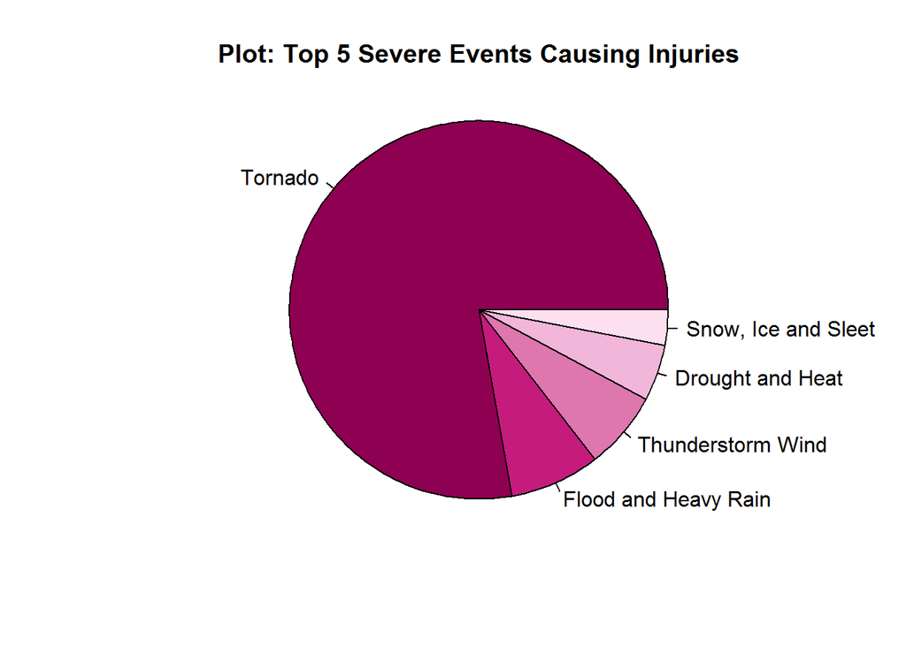

```r
# Pick top 5 events causing most injuries
injuries<-data.frame(injuries)
injuries<-injuries[order(injuries$INJURIES,decreasing = TRUE),][1:5,]

# Plotting a pie-chart
pie(injuries$INJURIES ,labels =injuries$EVNAME , edges = 200, radius = 1.0, angle = 90, col =brewer.pal(10,"PiYG") ,main = "Plot: Top 5 Severe Events Causing Injuries")
```

Top 5 events causing most injuries are as follows:

- 1.**Tornado**
- 2.**Flood and Heavy Rain**
- 3.**Thunderstorm Wind**
- 4.**Drought and Heat**
- 5.**Snow, Ice and Sleet**

Now, We will plot a piechart for 5 most deadliest event causing fatalities:

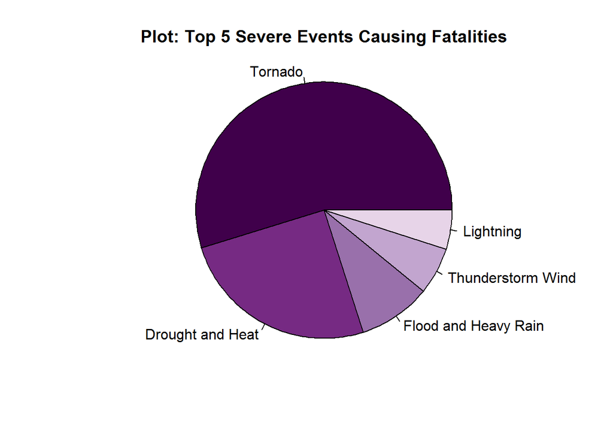

```r
# Pick top 5 events causing most fatalities
fatalities<-data.frame(fatalities)
fatalities<-fatalities[order(fatalities$FATALITIES,decreasing = TRUE),][1:5,]

# Plotting a pie-chart
pie(fatalities$FATALITIES ,labels =fatalities$EVNAME , edges = 200, radius = 1.0, angle = 90, col =brewer.pal(10,"PRGn") ,main = "Plot: Top 5 Severe Events Causing Fatalities")
```

Top 5 events causing most fatalities are as follows:

- 1.**Tornado**
- 2.**Drought and Heat**
- 3.**Flood and Heavy Rain**
- 4.**Thunderstorm Wind**
- 5.**Lightning**

**Across the United States, which types of events have the greatest economic consequences?**

We will calculate the sum of property damage and crop damage by event type. And then we will plot the damage.

```r
# Aggregating property damage and crop damage by event type
damage<-aggregate(TOTALPROPDMG+TOTALCROPDMG~EVNAME,data =TEMP,sum)
names(damage)<-c("EVNAME", "TOTALDAMAGE")

# Pick top 5 events causing most damage
damage<-data.frame(damage)
damage<-damage[order(damage$TOTALDAMAGE,decreasing = TRUE),][1:5,]
damage
```

```
##                   EVNAME TOTALDAMAGE
## 21               Tornado 39770610914
## 7   Flood and Heavy Rain 33399391439
## 13 Hurricane and Typhoon 15472350000
## 5       Drought and Heat  7908004430
## 18   Snow, Ice and Sleet  7871216970
```

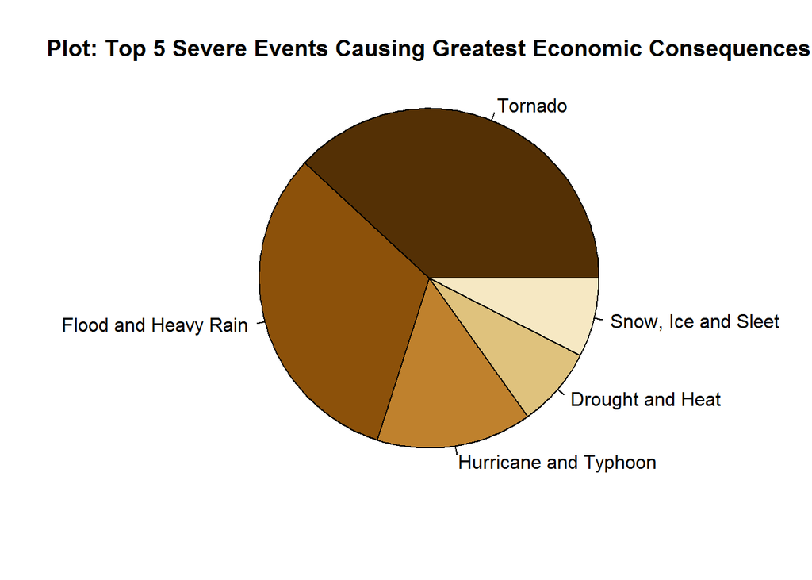

```r
# Plotting a pie-chart

 pie(damage$TOTALDAMAGE ,labels =damage$EVNAME , edges = 200, radius = 1.0, angle = 90, col =brewer.pal(10,"BrBG") ,main = "Plot: Top 5 Severe Events Causing Greatest Economic Consequences")
```

Top 5 events causing most economical damage are as follows:

- 1.**Tornado**
- 2.**Flood and Heavy Rain**
- 3.**Hurricane and Typhoon**
- 4.**Drought and Heat**
- 5.**Snow, Ice and Sleet**